# PCA_Results

Callie Stephenson

2024-09-25

# Question 1

## Loading the packages and data

## Building a PCA

When I make a PCA of

```
## [1] "Low_Tide_Mean_Salinity"        "Low_Tide_Mean_Phosphate_umolL"
## [3] "Low_Tide_Mean_Silicate_umolL"  "Low_Tide_Mean_NN_umolL"
## [5] "Low_Tide_Mean_NNP_umolL"
```

we can explain 72.2% of the variation of these factors with 1 axis.

```
## Importance of components:
##                           Comp.1    Comp.2     Comp.3     Comp.4       Comp.5
## Standard deviation     1.9006474 0.8665870 0.70511411 0.36661023 0.0705500099
## Proportion of Variance 0.7224921 0.1501946 0.09943718 0.02688061 0.0009954608
## Cumulative Proportion  0.7224921 0.8726867 0.97212393 0.99900454 1.0000000000
```

```
##
## Loadings:
##                               Comp.1 Comp.2 Comp.3 Comp.4 Comp.5
## Low_Tide_Mean_Salinity         0.403  0.104  0.902  0.119
## Low_Tide_Mean_Phosphate_umolL -0.399  0.703  0.170 -0.546 -0.140
## Low_Tide_Mean_Silicate_umolL  -0.478  0.336         0.808
## Low_Tide_Mean_NN_umolL        -0.493 -0.323  0.274 -0.160  0.743
## Low_Tide_Mean_NNP_umolL       -0.455 -0.527  0.280        -0.654
##
##                Comp.1 Comp.2 Comp.3 Comp.4 Comp.5
## SS loadings       1.0    1.0    1.0    1.0    1.0
## Proportion Var    0.2    0.2    0.2    0.2    0.2
## Cumulative Var    0.2    0.4    0.6    0.8    1.0
```

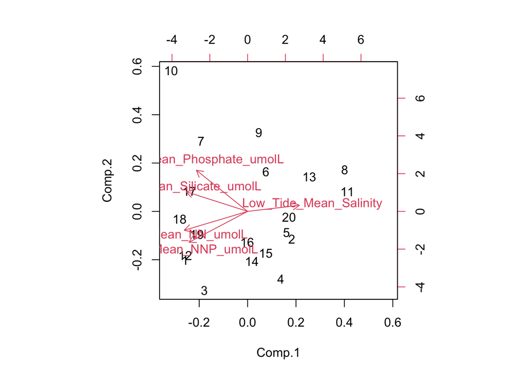

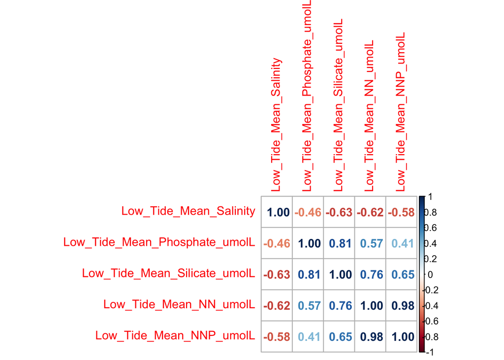

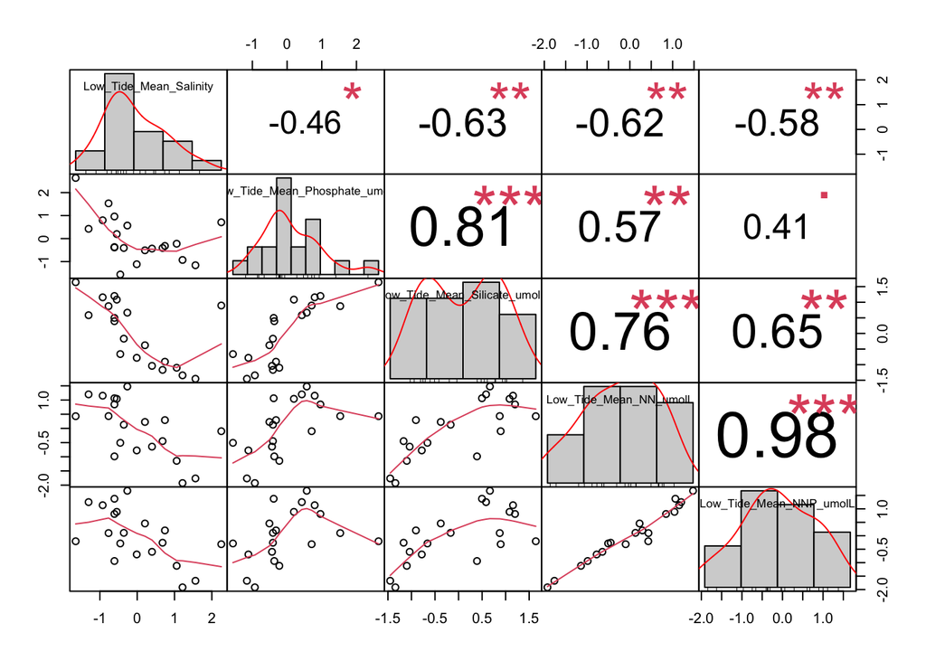

### PCA of sd - doesn’t work

```
## [1] "sd_Salinity"    "sd_Temperature" "sd_TA"          "sd_pH"
```

```
## Importance of components:
##                           Comp.1    Comp.2    Comp.3    Comp.4
## Standard deviation     1.2078567 1.0293285 0.9045391 0.8144777
## Proportion of Variance 0.3647295 0.2648793 0.2045478 0.1658435
## Cumulative Proportion  0.3647295 0.6296088 0.8341565 1.0000000
```

```
##
## Loadings:
##                Comp.1 Comp.2 Comp.3 Comp.4
## sd_Salinity     0.498  0.308  0.810
## sd_Temperature  0.627        -0.377  0.678
## sd_TA           0.143  0.862 -0.408 -0.263
## sd_pH          -0.582  0.394  0.187  0.686
##
##                Comp.1 Comp.2 Comp.3 Comp.4
## SS loadings      1.00   1.00   1.00   1.00
## Proportion Var   0.25   0.25   0.25   0.25
## Cumulative Var   0.25   0.50   0.75   1.00
```

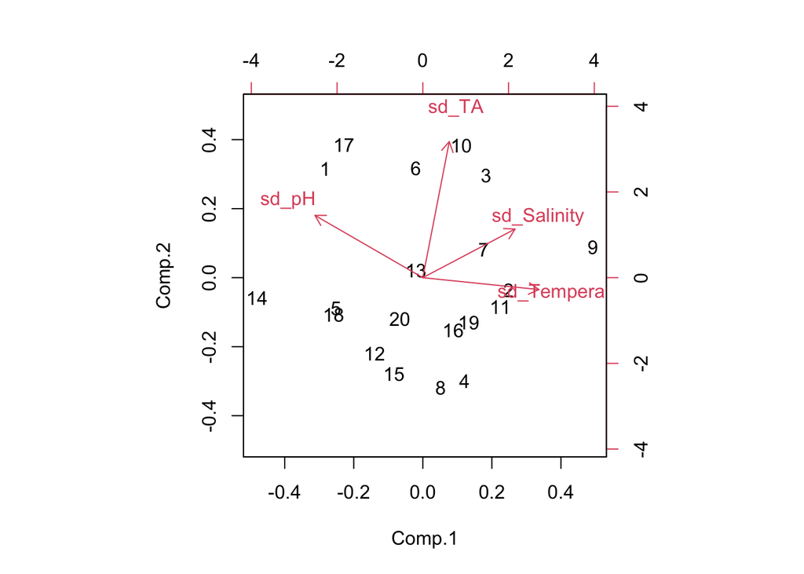

Here, the hollow yellow dot is the seep, and cooler colors have less nutrient influence, while more yellow colors have more nutrients at low tide.

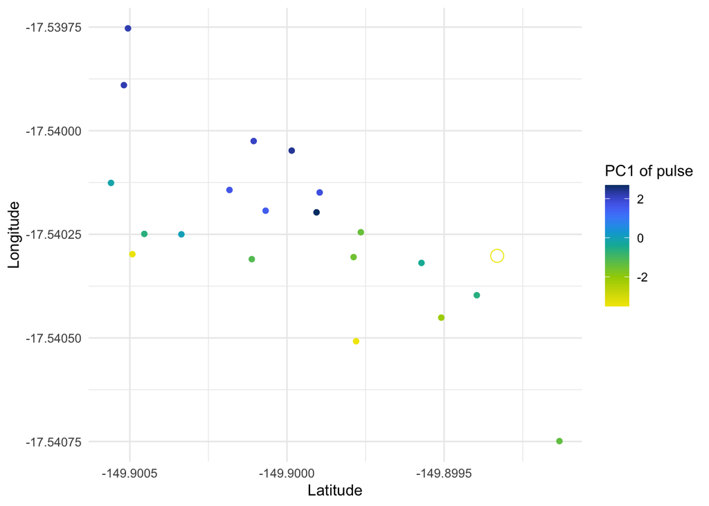

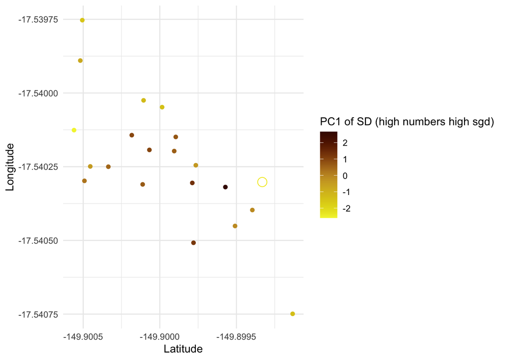

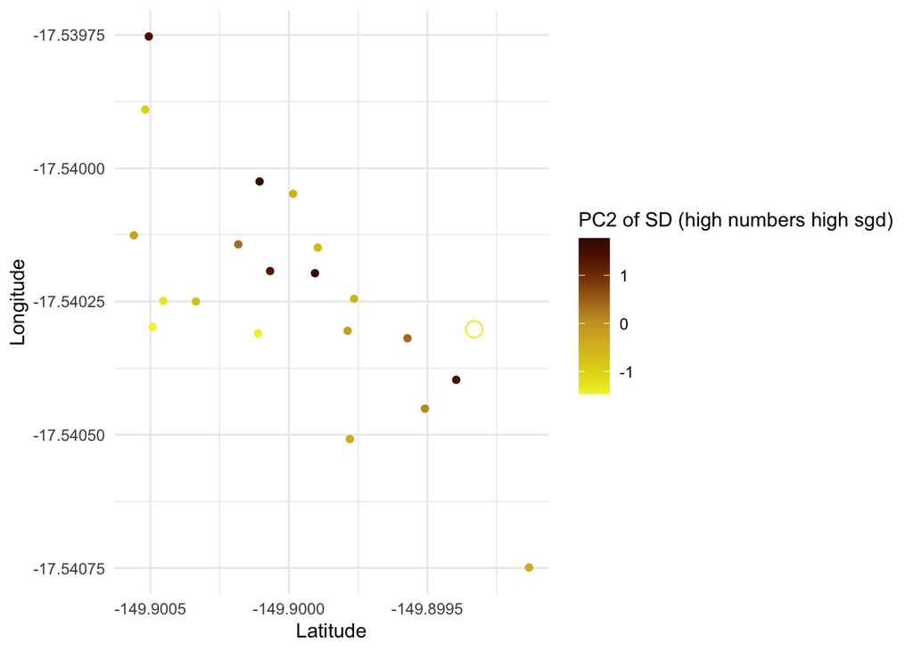

## Growth

### Pocillopora acuta

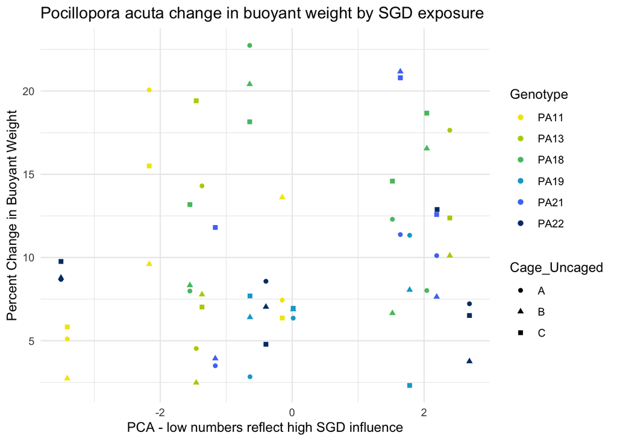

#### linear model:

```
## Analysis of Deviance Table (Type II Wald chisquare tests)
##
## Response: Percent_Change
##      Chisq Df Pr(>Chisq)
## pc1 1.7624  1     0.1843
```

This model does not support the hypothesis that nutriencts from SGD contribute to the variance in calcification in Pocillopora acuta

#### polynomial model:

```
## Analysis of Deviance Table (Type II Wald chisquare tests)
##
## Response: log10(Percent_Change)
##              Chisq Df Pr(>Chisq)
## poly(pc1, 2) 2.282  2     0.3195
```

[figure not shown]

This model does not support the hypothesis that nutriencts from SGD contribute to the variance in calcification in Pocillopora acuta

### Porites rus

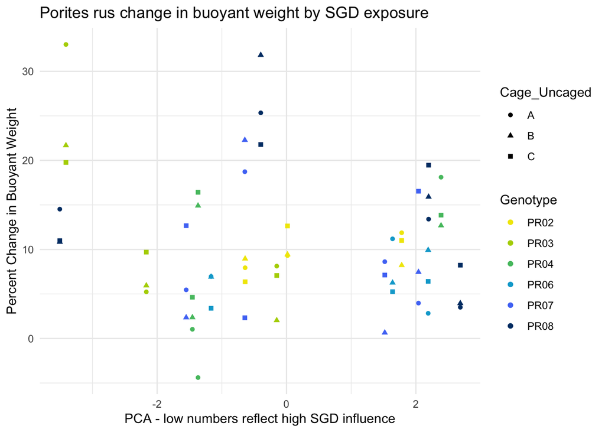

```
## Analysis of Deviance Table (Type II Wald chisquare tests)
##
## Response: Percent_Change
##     Chisq Df Pr(>Chisq)
## pc1  1.14  1     0.2857
```

We do not find support for pc1 affecting growth of Porites rus in a linear fashion

```
## Analysis of Deviance Table (Type II Wald chisquare tests)
##
## Response: Percent_Change
##               Chisq Df Pr(>Chisq)
## poly(pc1, 2) 3.1827  2     0.2037
```

We do not find support for pc1 affecting growth of Porites rus in a polynomial fashion

#### PRU but only caged

I also ran these models on a dataset with only caged corals:

```
## Analysis of Deviance Table (Type II Wald chisquare tests)
##
## Response: Percent_Change
##      Chisq Df Pr(>Chisq)
## pc1 0.0217  1      0.883
```

```
## Analysis of Deviance Table (Type II Wald chisquare tests)
##
## Response: Percent_Change
##               Chisq Df Pr(>Chisq)
## poly(pc1, 2) 1.5876  2     0.4521
```

When only looking at caged samples, we still don’t find any influence of PC1 on calcification

## Symbiont Count

### Pocillopora acuta

[figure not shown]

#### linear model

```
## Analysis of Deviance Table (Type II Wald chisquare tests)
##
## Response: log10(FSC.Events_per_cm_2)
##      Chisq Df Pr(>Chisq)
## pc1 0.0016  1      0.968
```

This model does not support the hypothesis that nutriencts from SGD contribute to the variance in symbiont density in Pocillopora acuta

#### polynomial model

```
## Analysis of Deviance Table (Type II Wald chisquare tests)
##
## Response: log10(FSC.Events_per_cm_2)
##               Chisq Df Pr(>Chisq)
## poly(pc1, 2) 3.6812  2     0.1587
```

This model does not support the hypothesis that nutriencts from SGD contribute to the variance in symbiont density in Pocillopora acuta

### Porites rus

[figure not shown]

#### linear model:

```
## Analysis of Deviance Table (Type II Wald chisquare tests)
##
## Response: log10(FSC.Events_per_cm_2)
##      Chisq Df Pr(>Chisq)
## pc1 1.1723  1     0.2789
```

We do not find support for pc1 affecting symb of Porites rus in a linear fashion

#### polynomial model:

```
## Analysis of Deviance Table (Type II Wald chisquare tests)
##
## Response: log10(FSC.Events_per_cm_2)
##               Chisq Df Pr(>Chisq)
## poly(pc1, 2) 2.9557  2     0.2281
```

We do not find support for pc1 affecting symb of Porites rus in a polynomial fashion

#### PRU but only caged

```
## Analysis of Deviance Table (Type II Wald chisquare tests)
##
## Response: log10(FSC.Events_per_cm_2)
##      Chisq Df Pr(>Chisq)
## pc1 0.2064  1     0.6496
```

```
## Analysis of Deviance Table (Type II Wald chisquare tests)
##
## Response: log10(FSC.Events_per_cm_2)
##               Chisq Df Pr(>Chisq)
## poly(pc1, 2) 0.4746  2     0.7888
```

This model does not support the hypothesis that nutriencts from SGD contribute to the variance in symbiont density in Porites rus

## Heterotrophy

### Exploratory plots

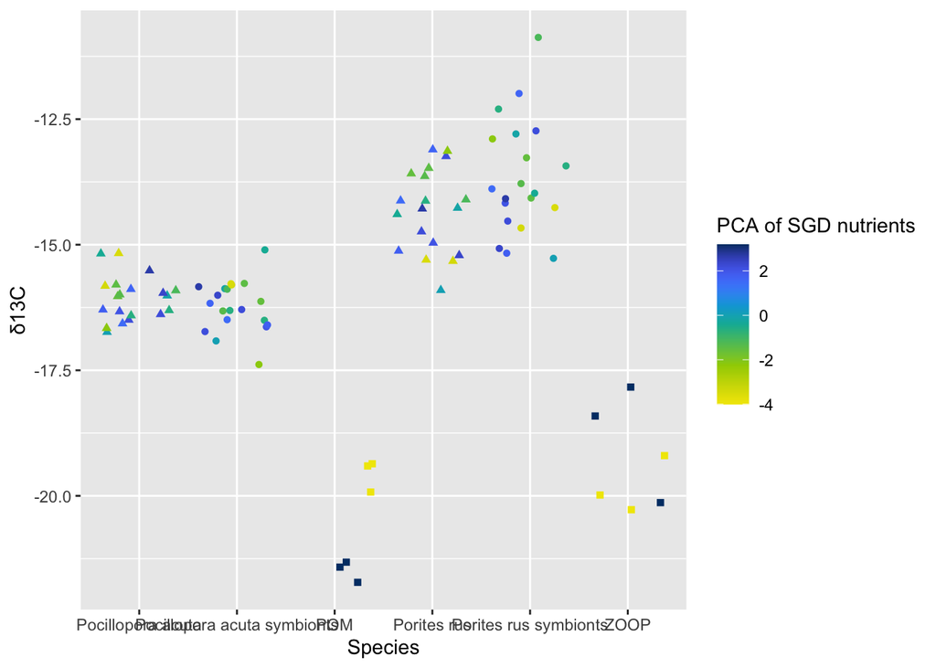

Instead of coloring by the pc axis, this is using the pc as the x-axis with 13C as the response and colored/shaped by species:

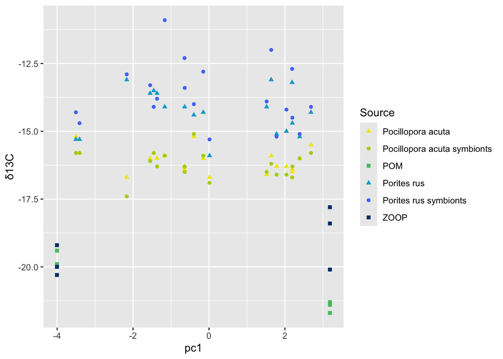

to see how the coral host vs symb nitrogen looks against the potential sources (zooplankton and pom)

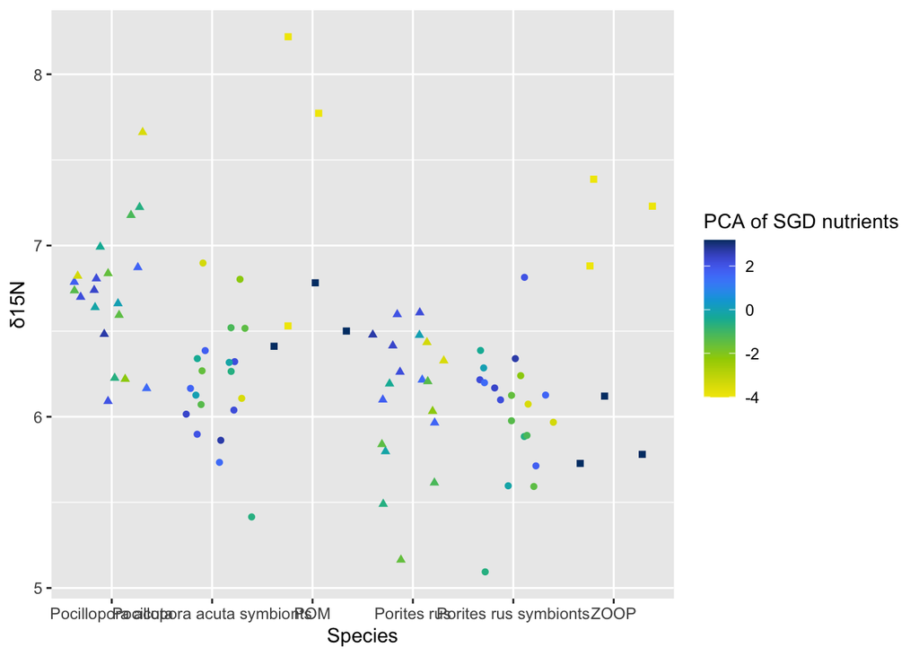

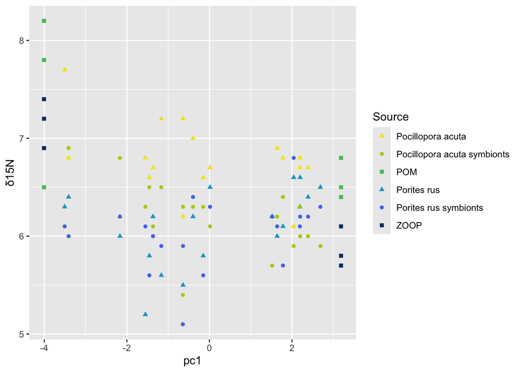

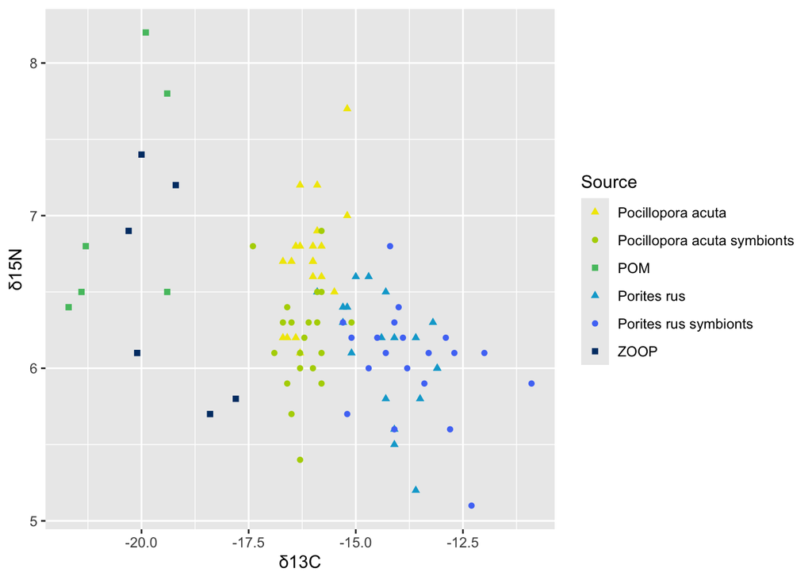

## Carbon

### Pocillopora acuta

#### Exploratory plot:

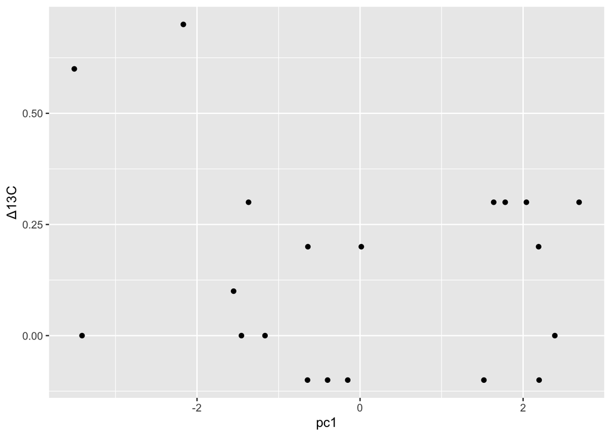

#### Linear model:

```
## Analysis of Deviance Table (Type II Wald chisquare tests)
##
## Response: Δ13C
##      Chisq Df Pr(>Chisq)
## pc1 0.7103  1     0.3993
```

Not significant

#### Polynomial model:

```
## Analysis of Deviance Table (Type II Wald chisquare tests)
##
## Response: Δ13C
##               Chisq Df Pr(>Chisq)
## poly(pc1, 2) 3.3642  2      0.186
```

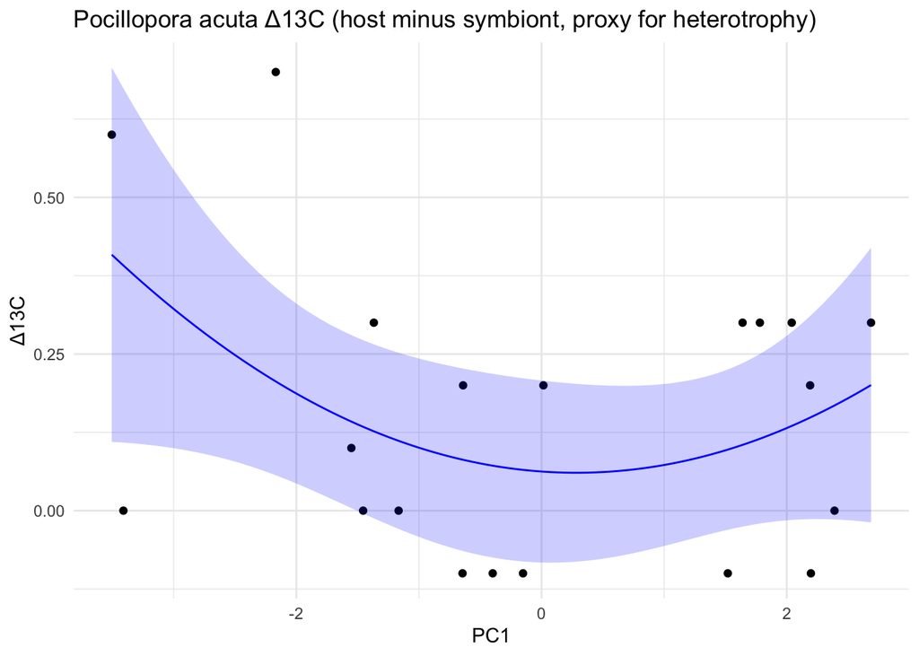

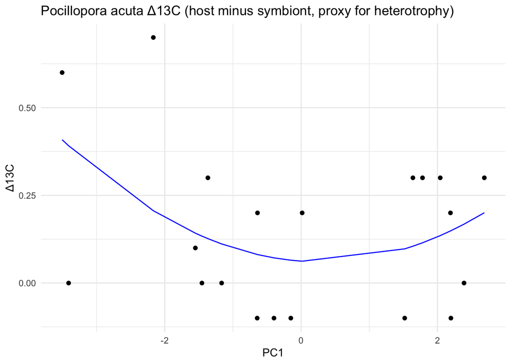

### Porites rus

#### Exploratory plot:

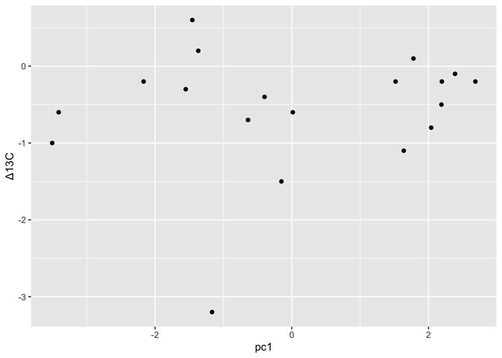

#### Linear model:

```
## Analysis of Deviance Table (Type II Wald chisquare tests)
##
## Response: Δ13C
##      Chisq Df Pr(>Chisq)
## pc1 0.9124  1     0.3395
```

Not significant

#### Polynomial model:

```
## Analysis of Deviance Table (Type II Wald chisquare tests)
##
## Response: Δ13C
##               Chisq Df Pr(>Chisq)
## poly(pc1, 2) 1.3814  2     0.5012
```

Not significant

## Nitrogen

### Pocillopora acuta

#### Exploratory plot:

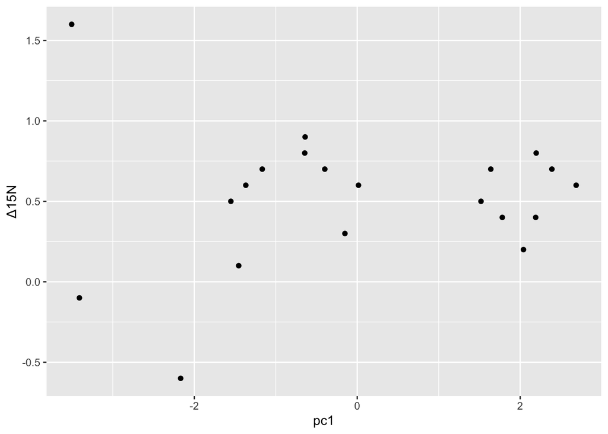

#### Linear model:

```
## Analysis of Deviance Table (Type II Wald chisquare tests)
##
## Response: Δ15N
##      Chisq Df Pr(>Chisq)
## pc1 0.8595  1     0.3539
```

Not significant

#### Polynomial model:

```
## Analysis of Deviance Table (Type II Wald chisquare tests)
##
## Response: Δ15N
##               Chisq Df Pr(>Chisq)
## poly(pc1, 2) 0.8028  2     0.6694
```

Not significant

### Porites rus

#### Exploratory plot:

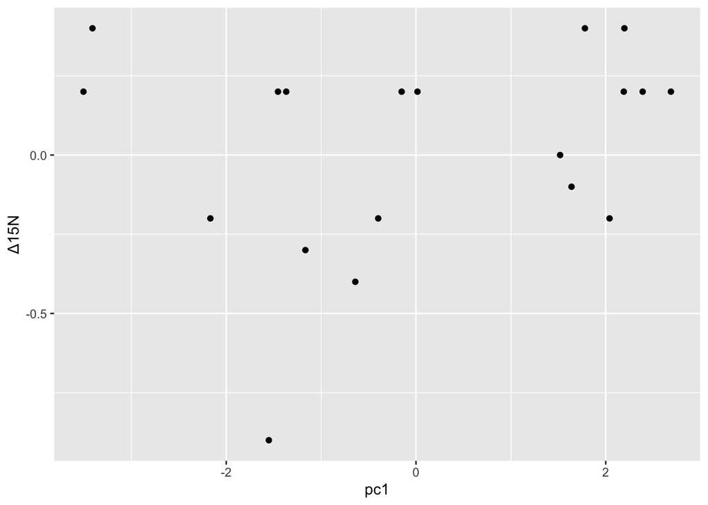

#### Linear model:

```
## Analysis of Deviance Table (Type II Wald chisquare tests)
##
## Response: Δ15N
##      Chisq Df Pr(>Chisq)
## pc1 1.6781  1     0.1952
```

Not significant

#### Polynomial model:

```
## Analysis of Deviance Table (Type II Wald chisquare tests)
##
## Response: Δ15N
##               Chisq Df Pr(>Chisq)
## poly(pc1, 2) 7.1289  2    0.02831 *
## ---
## Signif. codes:  0 '***' 0.001 '**' 0.01 '*' 0.05 '.' 0.1 ' ' 1
```

Significant

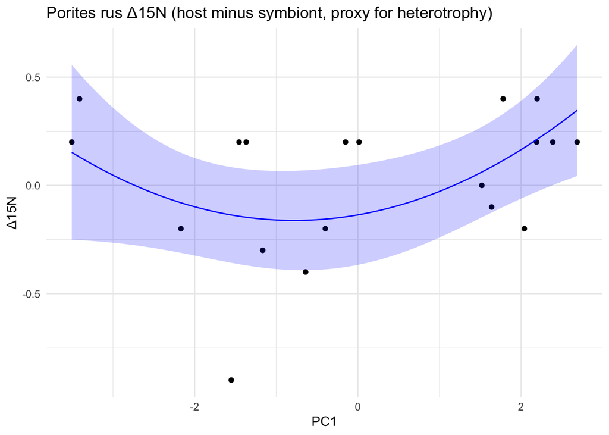

[figure not shown]

# Question 2

## Collinearity

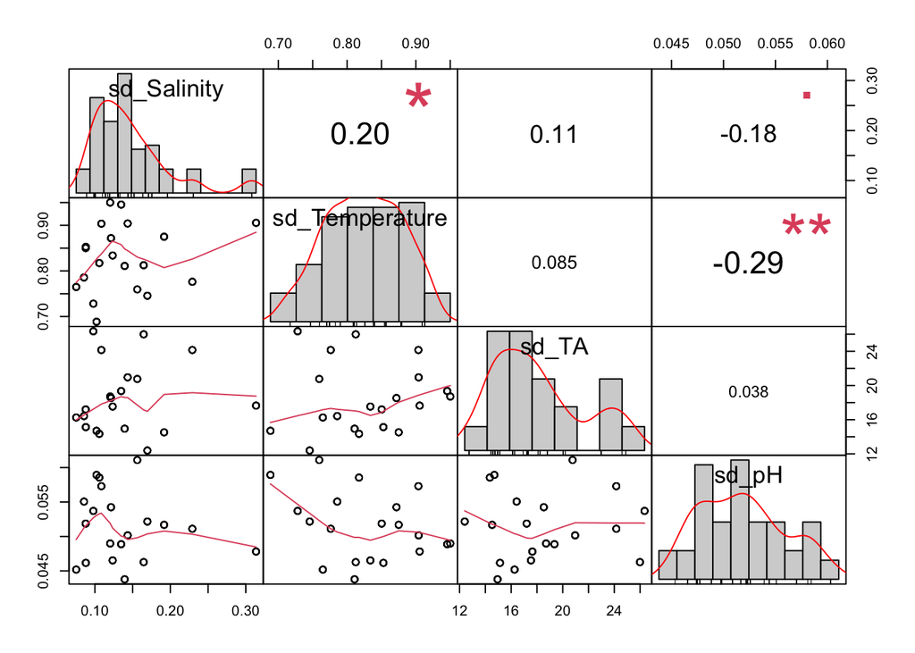

## Growth

### PAC

```
## 21 x 1 sparse Matrix of class "dgCMatrix"
##                          s1
## (Intercept)    -30.34830067
## sd_TA            0.39799434
## sd_pH          454.32376597
## sd_Salinity      .
## sd_Temperature  11.75650231
## GenotypePA11     .
## GenotypePA13     .
## GenotypePA18     .
## GenotypePA19     .
## GenotypePA21     2.55900775
## GenotypePA22    -1.83990742
## GenotypePR02     .
## GenotypePR03     .
## GenotypePR04     .
## GenotypePR06     .
## GenotypePR07     .
## GenotypePR08     .
## Cage_UncagedA    .
## Cage_UncagedB   -0.06351007
## Cage_UncagedC    0.61165316
## Cage_UncagedT0   .
```

#### Significant model

```
## Linear mixed model fit by REML ['lmerMod']
## Formula: Percent_Change ~ sd_Temperature + sd_TA + sd_pH + (1 | Genotype) +
##     (1 | Cage_Uncaged)
##    Data: model_data %>% filter(Species == "Pocillopora acuta")
##
## REML criterion at convergence: 314.3
##
## Scaled residuals:
##      Min       1Q   Median       3Q      Max
## -2.05511 -0.60060 -0.07507  0.78966  2.33111
##
## Random effects:
##  Groups       Name        Variance Std.Dev.
##  Genotype     (Intercept)  6.898   2.6264
##  Cage_Uncaged (Intercept)  0.628   0.7925
##  Residual                 14.327   3.7850
## Number of obs: 59, groups:  Genotype, 6; Cage_Uncaged, 3
##
## Fixed effects:
##                Estimate Std. Error t value
## (Intercept)    -56.4103    10.8734  -5.188
## sd_Temperature  25.1926     7.4450   3.384
## sd_TA            0.5847     0.1787   3.271
## sd_pH          683.6086   129.4655   5.280
##
## Correlation of Fixed Effects:
##             (Intr) sd_Tmp sd_TA
## sd_Tempertr -0.751
## sd_TA       -0.318  0.047
## sd_pH       -0.761  0.275 -0.013
```

```
## Analysis of Deviance Table (Type II Wald chisquare tests)
##
## Response: Percent_Change
##                 Chisq Df Pr(>Chisq)
## sd_Temperature 11.450  1  0.0007149 ***
## sd_TA          10.702  1  0.0010704 **
## sd_pH          27.881  1   1.29e-07 ***
## ---
## Signif. codes:  0 '***' 0.001 '**' 0.01 '*' 0.05 '.' 0.1 ' ' 1
```

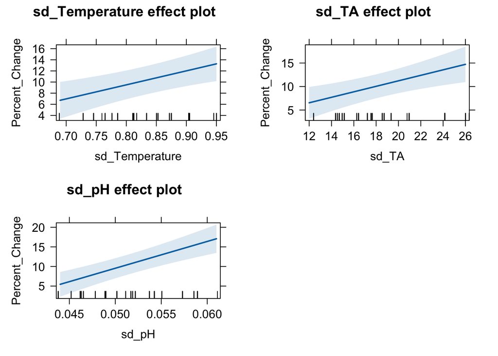

### PRU

```
## 21 x 1 sparse Matrix of class "dgCMatrix"
##                     s1
## (Intercept)    10.4174
## sd_TA           .
## sd_pH           .
## sd_Salinity     .
## sd_Temperature  .
## GenotypePA11    .
## GenotypePA13    .
## GenotypePA18    .
## GenotypePA19    .
## GenotypePA21    .
## GenotypePA22    .
## GenotypePR02    .
## GenotypePR03    .
## GenotypePR04    .
## GenotypePR06    .
## GenotypePR07    .
## GenotypePR08    .
## Cage_UncagedA   .
## Cage_UncagedB   .
## Cage_UncagedC   .
## Cage_UncagedT0  .
```

### PRU Caged Only

```
## 17 x 1 sparse Matrix of class "dgCMatrix"
##                      s1
## (Intercept)    10.78162
## sd_TA           .
## sd_pH           .
## sd_Salinity     .
## sd_Temperature  .
## GenotypePA11    .
## GenotypePA13    .
## GenotypePA18    .
## GenotypePA19    .
## GenotypePA21    .
## GenotypePA22    .
## GenotypePR02    .
## GenotypePR03    .
## GenotypePR04    .
## GenotypePR06    .
## GenotypePR07    .
## GenotypePR08    .
```

## Symb Abundance

### PAC

```
## 21 x 1 sparse Matrix of class "dgCMatrix"
##                      s1
## (Intercept)    4.046685
## sd_TA          .
## sd_pH          .
## sd_Salinity    .
## sd_Temperature .
## GenotypePA11   .
## GenotypePA13   .
## GenotypePA18   .
## GenotypePA19   .
## GenotypePA21   .
## GenotypePA22   .
## GenotypePR02   .
## GenotypePR03   .
## GenotypePR04   .
## GenotypePR06   .
## GenotypePR07   .
## GenotypePR08   .
## Cage_UncagedA  .
## Cage_UncagedB  .
## Cage_UncagedC  .
## Cage_UncagedT0 .
```

### PRU

```
## 21 x 1 sparse Matrix of class "dgCMatrix"
##                      s1
## (Intercept)    4.552976
## sd_TA          .
## sd_pH          .
## sd_Salinity    .
## sd_Temperature .
## GenotypePA11   .
## GenotypePA13   .
## GenotypePA18   .
## GenotypePA19   .
## GenotypePA21   .
## GenotypePA22   .
## GenotypePR02   .
## GenotypePR03   .
## GenotypePR04   .
## GenotypePR06   .
## GenotypePR07   .
## GenotypePR08   .
## Cage_UncagedA  .
## Cage_UncagedB  .
## Cage_UncagedC  .
## Cage_UncagedT0 .
```

#### PRU Caged Only

```
## 17 x 1 sparse Matrix of class "dgCMatrix"
##                      s1
## (Intercept)    4.595715
## sd_TA          .
## sd_pH          .
## sd_Salinity    .
## sd_Temperature .
## GenotypePA11   .
## GenotypePA13   .
## GenotypePA18   .
## GenotypePA19   .
## GenotypePA21   .
## GenotypePA22   .
## GenotypePR02   .
## GenotypePR03   .
## GenotypePR04   .
## GenotypePR06   .
## GenotypePR07   .
## GenotypePR08   .
```

whole lotta nothing

## Heterotrophy

### Carbon

#### PAC

```
## 21 x 1 sparse Matrix of class "dgCMatrix"
##                  s1
## (Intercept)    0.15
## sd_TA          .
## sd_pH          .
## sd_Salinity    .
## sd_Temperature .
## GenotypePA11   .
## GenotypePA13   .
## GenotypePA18   .
## GenotypePA19   .
## GenotypePA21   .
## GenotypePA22   .
## GenotypePR02   .
## GenotypePR03   .
## GenotypePR04   .
## GenotypePR06   .
## GenotypePR07   .
## GenotypePR08   .
## Cage_UncagedA  .
## Cage_UncagedB  .
## Cage_UncagedC  .
## Cage_UncagedT0 .
```

#### PRU

```
## 21 x 1 sparse Matrix of class "dgCMatrix"
##                        s1
## (Intercept)    -0.5631579
## sd_TA           .
## sd_pH           .
## sd_Salinity     .
## sd_Temperature  .
## GenotypePA11    .
## GenotypePA13    .
## GenotypePA18    .
## GenotypePA19    .
## GenotypePA21    .
## GenotypePA22    .
## GenotypePR02    .
## GenotypePR03    .
## GenotypePR04    .
## GenotypePR06    .
## GenotypePR07    .
## GenotypePR08    .
## Cage_UncagedA   .
## Cage_UncagedB   .
## Cage_UncagedC   .
## Cage_UncagedT0  .
```

nothin again

### Nitrogen

#### PAC

```
## 21 x 1 sparse Matrix of class "dgCMatrix"
##                        s1
## (Intercept)     0.5480783
## sd_TA           .
## sd_pH           .
## sd_Salinity     .
## sd_Temperature  .
## GenotypePA11   -0.1871890
## GenotypePA13    .
## GenotypePA18    .
## GenotypePA19    .
## GenotypePA21    .
## GenotypePA22    .
## GenotypePR02    .
## GenotypePR03    .
## GenotypePR04    .
## GenotypePR06    .
## GenotypePR07    .
## GenotypePR08    .
## Cage_UncagedA   .
## Cage_UncagedB   .
## Cage_UncagedC   .
## Cage_UncagedT0  .
```

#### PRU

```
## 21 x 1 sparse Matrix of class "dgCMatrix"
##                        s1
## (Intercept)    0.02631579
## sd_TA          .
## sd_pH          .
## sd_Salinity    .
## sd_Temperature .
## GenotypePA11   .
## GenotypePA13   .
## GenotypePA18   .
## GenotypePA19   .
## GenotypePA21   .
## GenotypePA22   .
## GenotypePR02   .
## GenotypePR03   .
## GenotypePR04   .
## GenotypePR06   .
## GenotypePR07   .
## GenotypePR08   .
## Cage_UncagedA  .
## Cage_UncagedB  .
## Cage_UncagedC  .
## Cage_UncagedT0 .
```